# Investigate a Dataset - [Medical Appointment No Shows 2016]

- Introduction
- Data Wrangling
- Exploratory Data Analysis
- Conclusions

## Introduction

This dataset collects information from 100k medical appointments in Brazil and is focused on the question of whether or not patients show up for their appointment.

### Dataset Description

- **PatientId:** Identification of a patient.
- **AppointmentID:** Identification of each appointment.
- **Gender:** Male or Female.
- **ScheduledDay:** tells us on what day the patient set up their appointment.
- **AppointmentDay:** tells us on what day the patient should come for the treatment.
- **Age:** How old is the patient.
- **Neighborhood:** indicates the location of the hospital.
- **Scholarship:** indicates whether or not the patient is enrolled in Brasilian welfare program [Bolsa Família](https://en.wikipedia.org/wiki/Bolsa_Fam%C3%ADlia).
- **Hipertension:** true or false.
- **Diabetes:** true or false.
- **Alcoholism:** true or false.
- **Handcap:** true or false.
- **SMS_received:** 1 or more messages sent to the patient.
- **no show:** it says `‘No’` if the patient showed up to their appointment, and `‘Yes’` if they did not show up.

### Question(s) for Analysis

- **Is there a relationship between age and non-attendance?**
- **Does gender and age affect attendance?**
- **Is there a relationship between age, gender, and disease?**
- **Is there a relationship between sms and non-attendance?**
- **Does neighbourhood affect attendance?**

```python
import datetime
import numpy as np
import pandas as pd
import seaborn as sns
import matplotlib.pyplot as plt
%matplotlib inline
```

## Data Wrangling

we will load in the data, check for cleanliness, and then trim and clean our dataset for analysis

### General Properties

```python
# Loading the data
df = pd.read_csv('noshowappointments-kagglev2-may-2016.csv')
```

```python
# Displaying the first 5 rows
df.head()
```

|  | PatientId | AppointmentID | Gender | ScheduledDay | AppointmentDay | Age | Neighbourhood | Scholarship | Hipertension | Diabetes | Alcoholism | Handcap | SMS_received | No-show |
| --- | --- | --- | --- | --- | --- | --- | --- | --- | --- | --- | --- | --- | --- | --- |
| 0 | 2.987250e+13 | 5642903 | F | 2016-04-29T18:38:08Z | 2016-04-29T00:00:00Z | 62 | JARDIM DA PENHA | 0 | 1 | 0 | 0 | 0 | 0 | No |
| 1 | 5.589978e+14 | 5642503 | M | 2016-04-29T16:08:27Z | 2016-04-29T00:00:00Z | 56 | JARDIM DA PENHA | 0 | 0 | 0 | 0 | 0 | 0 | No |
| 2 | 4.262962e+12 | 5642549 | F | 2016-04-29T16:19:04Z | 2016-04-29T00:00:00Z | 62 | MATA DA PRAIA | 0 | 0 | 0 | 0 | 0 | 0 | No |
| 3 | 8.679512e+11 | 5642828 | F | 2016-04-29T17:29:31Z | 2016-04-29T00:00:00Z | 8 | PONTAL DE CAMBURI | 0 | 0 | 0 | 0 | 0 | 0 | No |
| 4 | 8.841186e+12 | 5642494 | F | 2016-04-29T16:07:23Z | 2016-04-29T00:00:00Z | 56 | JARDIM DA PENHA | 0 | 1 | 1 | 0 | 0 | 0 | No |

### Assessing

```python
# Checking to see if any data is missing!
df.info()
```

```
<class 'pandas.core.frame.DataFrame'>
RangeIndex: 110527 entries, 0 to 110526
Data columns (total 14 columns):
 #   Column          Non-Null Count   Dtype
---  ------          --------------   -----
 0   PatientId       110527 non-null  float64
 1   AppointmentID   110527 non-null  int64
 2   Gender          110527 non-null  object
 3   ScheduledDay    110527 non-null  object
 4   AppointmentDay  110527 non-null  object
 5   Age             110527 non-null  int64
 6   Neighbourhood   110527 non-null  object
 7   Scholarship     110527 non-null  int64
 8   Hipertension    110527 non-null  int64
 9   Diabetes        110527 non-null  int64
 10  Alcoholism      110527 non-null  int64
 11  Handcap         110527 non-null  int64
 12  SMS_received    110527 non-null  int64
 13  No-show         110527 non-null  object
dtypes: float64(1), int64(8), object(5)
memory usage: 11.8+ MB
```

```python
# How many rows and columns does this data contain?
df.shape
```

```
(110527, 14)
```

```python
# Examine any missing data rows!
df.isnull().sum()
```

```
PatientId         0
AppointmentID     0
Gender            0
ScheduledDay      0
AppointmentDay    0
Age               0
Neighbourhood     0
Scholarship       0
Hipertension      0
Diabetes          0
Alcoholism        0
Handcap           0
SMS_received      0
No-show           0
dtype: int64
```

```python
# Checking if there are any duplicated data
df.duplicated().sum()
```

```
0
```

It's looks like there are no missing data or duplicated rows.

```python
# checking the unique values
df.nunique()
```

```
PatientId          62299
AppointmentID     110527
Gender                 2
ScheduledDay      103549
AppointmentDay        27
Age                  104
Neighbourhood         81
Scholarship            2
Hipertension           2
Diabetes               2
Alcoholism             2
Handcap                5
SMS_received           2
No-show                2
dtype: int64
```

As we can see, there are 62299 unique ids, implying that duplicate ids exist.

```python
# is there any duplicated ids?
df.PatientId.duplicated().sum()
```

```
48228
```

It appears that we have duplicates that need to be removed.

```python
# what is the data types?
df.dtypes
```

```
PatientId         float64
AppointmentID       int64
Gender             object
ScheduledDay       object
AppointmentDay     object
Age                 int64
Neighbourhood      object
Scholarship         int64
Hipertension        int64
Diabetes            int64
Alcoholism          int64
Handcap             int64
SMS_received        int64
No-show            object
dtype: object
```

it seems like ScheduledDay and AppointmentDay are objects we have to change them to a datetime.

```python
df['ScheduledDay'] = pd.to_datetime(df['ScheduledDay'])
df['AppointmentDay'] = pd.to_datetime(df['AppointmentDay'])
```

```python
#checking if the types have changed
df['ScheduledDay'].dtype , df['AppointmentDay'].dtype
```

```
(datetime64[ns, UTC], datetime64[ns, UTC])
```

```python
# checking the data
df.head()
```

|  | PatientId | AppointmentID | Gender | ScheduledDay | AppointmentDay | Age | Neighbourhood | Scholarship | Hipertension | Diabetes | Alcoholism | Handcap | SMS_received | No-show |
| --- | --- | --- | --- | --- | --- | --- | --- | --- | --- | --- | --- | --- | --- | --- |
| 0 | 2.987250e+13 | 5642903 | F | 2016-04-29 18:38:08+00:00 | 2016-04-29 00:00:00+00:00 | 62 | JARDIM DA PENHA | 0 | 1 | 0 | 0 | 0 | 0 | No |
| 1 | 5.589978e+14 | 5642503 | M | 2016-04-29 16:08:27+00:00 | 2016-04-29 00:00:00+00:00 | 56 | JARDIM DA PENHA | 0 | 0 | 0 | 0 | 0 | 0 | No |
| 2 | 4.262962e+12 | 5642549 | F | 2016-04-29 16:19:04+00:00 | 2016-04-29 00:00:00+00:00 | 62 | MATA DA PRAIA | 0 | 0 | 0 | 0 | 0 | 0 | No |
| 3 | 8.679512e+11 | 5642828 | F | 2016-04-29 17:29:31+00:00 | 2016-04-29 00:00:00+00:00 | 8 | PONTAL DE CAMBURI | 0 | 0 | 0 | 0 | 0 | 0 | No |
| 4 | 8.841186e+12 | 5642494 | F | 2016-04-29 16:07:23+00:00 | 2016-04-29 00:00:00+00:00 | 56 | JARDIM DA PENHA | 0 | 1 | 1 | 0 | 0 | 0 | No |

```python
# checking the statistics
df.describe()
```

|  | PatientId | AppointmentID | Age | Scholarship | Hipertension | Diabetes | Alcoholism | Handcap | SMS_received |
| --- | --- | --- | --- | --- | --- | --- | --- | --- | --- |
| count | 1.105270e+05 | 1.105270e+05 | 110527.000000 | 110527.000000 | 110527.000000 | 110527.000000 | 110527.000000 | 110527.000000 | 110527.000000 |
| mean | 1.474963e+14 | 5.675305e+06 | 37.088874 | 0.098266 | 0.197246 | 0.071865 | 0.030400 | 0.022248 | 0.321026 |
| std | 2.560949e+14 | 7.129575e+04 | 23.110205 | 0.297675 | 0.397921 | 0.258265 | 0.171686 | 0.161543 | 0.466873 |
| min | 3.921784e+04 | 5.030230e+06 | -1.000000 | 0.000000 | 0.000000 | 0.000000 | 0.000000 | 0.000000 | 0.000000 |
| 25% | 4.172614e+12 | 5.640286e+06 | 18.000000 | 0.000000 | 0.000000 | 0.000000 | 0.000000 | 0.000000 | 0.000000 |
| 50% | 3.173184e+13 | 5.680573e+06 | 37.000000 | 0.000000 | 0.000000 | 0.000000 | 0.000000 | 0.000000 | 0.000000 |
| 75% | 9.439172e+13 | 5.725524e+06 | 55.000000 | 0.000000 | 0.000000 | 0.000000 | 0.000000 | 0.000000 | 1.000000 |
| max | 9.999816e+14 | 5.790484e+06 | 115.000000 | 1.000000 | 1.000000 | 1.000000 | 1.000000 | 4.000000 | 1.000000 |

As we can see, there is something wrong at the age column there is a minus number, so we have to check that.

```python
df.Age.value_counts()
```

```
 0      3539
 1      2273
 52     1746
 49     1652
 53     1651
        ...
 115       5
 100       4
 102       2
 99        1
-1         1
Name: Age, Length: 104, dtype: int64
```

As we can see, there are 3539 rows with age 0, which I think are babies i'm not sure, so we can keep that and simply delete the minus age,in the last row.

### Data Cleaning

```python
# removing the minus age row
minus_Age = df[df['Age'] == -1]
df.drop(minus_Age.index, inplace=True)
```

```python
# removing the duplicated IDs
df.drop_duplicates('PatientId',inplace=True)
```

**Now I am going to rename the data columns and delete the unnecessary columns.**

```python
# changing the names of Hipertension , No-show and Handcap
df.rename(columns={'Hipertension':'Hypertension','No-show':'No_show','Handcap':'Handicap'},inplace=True)
```

```python
# removing unnecessary columns
df.drop(['PatientId','AppointmentID'] ,axis=1, inplace=True)
```

```python
df.rename(columns=lambda x: x.strip().lower(),inplace=True)
```

## Exploratory Data Analysis

### Research Question 1 (Is there a relationship between age and non-attendance?)

```python
df.head()
```

|  | gender | scheduledday | appointmentday | age | neighbourhood | scholarship | hypertension | diabetes | alcoholism | handicap | sms_received | no_show |
| --- | --- | --- | --- | --- | --- | --- | --- | --- | --- | --- | --- | --- |
| 0 | F | 2016-04-29 18:38:08+00:00 | 2016-04-29 00:00:00+00:00 | 62 | JARDIM DA PENHA | 0 | 1 | 0 | 0 | 0 | 0 | No |
| 1 | M | 2016-04-29 16:08:27+00:00 | 2016-04-29 00:00:00+00:00 | 56 | JARDIM DA PENHA | 0 | 0 | 0 | 0 | 0 | 0 | No |
| 2 | F | 2016-04-29 16:19:04+00:00 | 2016-04-29 00:00:00+00:00 | 62 | MATA DA PRAIA | 0 | 0 | 0 | 0 | 0 | 0 | No |
| 3 | F | 2016-04-29 17:29:31+00:00 | 2016-04-29 00:00:00+00:00 | 8 | PONTAL DE CAMBURI | 0 | 0 | 0 | 0 | 0 | 0 | No |
| 4 | F | 2016-04-29 16:07:23+00:00 | 2016-04-29 00:00:00+00:00 | 56 | JARDIM DA PENHA | 0 | 1 | 1 | 0 | 0 | 0 | No |

```python
# Checking the statistics of age
df.age.describe()
```

```
count    62298.000000
mean        36.705496
std         23.531076
min          0.000000
25%         17.000000
50%         36.000000
75%         56.000000
max        115.000000
Name: age, dtype: float64
```

```python
bin_names = ['Childhood','Adult','Middle Age Adult','Elderly']
bin_edges = [0,17,36,56,115]
df['age_stages'] = pd.cut(df.age , bin_edges ,labels=bin_names)
```

```python
age_stages = df.groupby('age_stages').age.mean()
age_stages
```

```
age_stages
Childhood            8.177474
Adult               26.984146
Middle Age Adult    46.751061
Elderly             68.100610
Name: age, dtype: float64
```

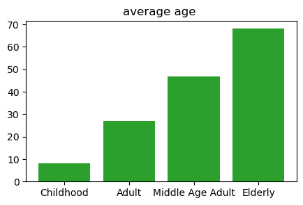

```python
# Create a bar chart for age
plt.subplots(figsize=(5,3));
plt.bar(age_stages.index , age_stages , color="C02");
plt.title('average age ');
```

**making a filter for patiants**

```python
no_attend = df['no_show']=='Yes'
attend = df['no_show']=='No'
```

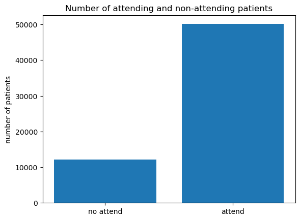

```python
# how many patients attending the appointment?
plt.bar(["no attend",'attend'],[df[no_attend].shape[0],df[attend].shape[0]]);
plt.title('Number of attending and non-attending patients');
plt.ylabel('number of patients');
```

```python
df[no_attend].shape[0],df[attend].shape[0]
```

```
(12193, 50105)
```

As we can see, 12193 patients didn't attend the appointment.

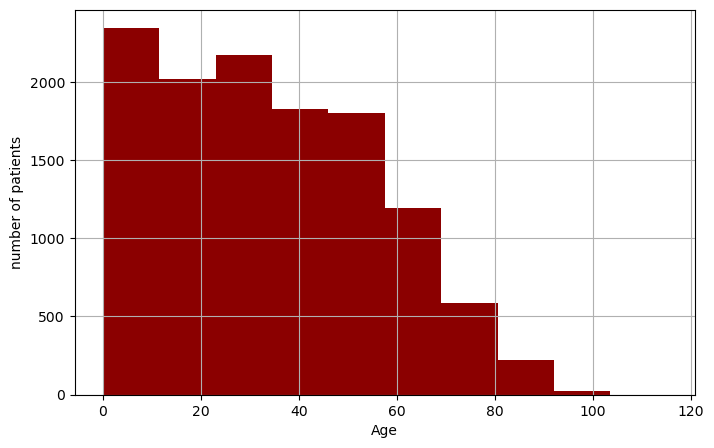

```python
# a hist for patients didn't attend
df[no_attend]['age'].hist(figsize=(8,5),color="darkred" );
plt.ylabel('number of patients');
plt.xlabel("Age");
```

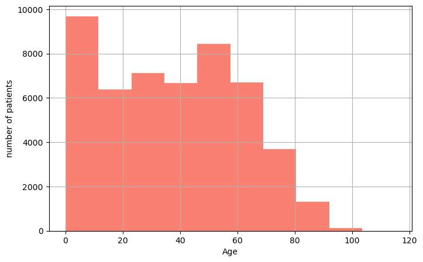

```python
# a hist for patients attended
df[attend]['age'].hist(figsize=(8,5),color="salmon");
plt.ylabel('number of patients');
plt.xlabel("Age");
```

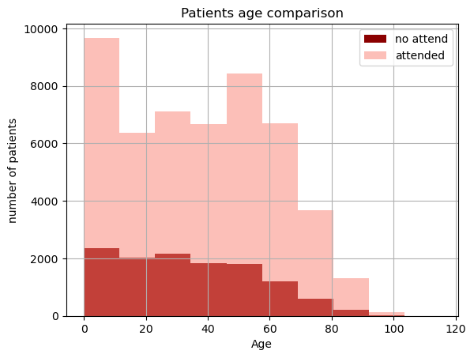

```python
# Comparing attendance and non-attendance
df[no_attend]["age"].plot(kind="hist", alpha= 1 ,color="darkred", label="no attend", grid=True);
df[attend]["age"].plot( kind="hist",alpha = .5,color="salmon", label="attended", grid=True);
plt.legend();
plt.title('Patients age comparison')
plt.xlabel("Age");
plt.ylabel('number of patients');
```

```python
df[attend]["age"].value_counts() , df[no_attend]["age"].value_counts()
```

```
(0      1680
 1      1169
 2       921
 3       799
 56      763
        ...
 98        3
 100       3
 102       2
 99        1
 115       1
 Name: age, Length: 103, dtype: int64,
 0      393
 1      274
 19     211
 21     210
 17     209
       ...
 95       2
 97       2
 98       1
 115      1
 96       1
 Name: age, Length: 100, dtype: int64)
```

As we can see, a lot of patients attending the appointment.

### Research Question 2 (Does gender and age affect attendance?)

```python
df.head()
```

|  | gender | scheduledday | appointmentday | age | neighbourhood | scholarship | hypertension | diabetes | alcoholism | handicap | sms_received | no_show | age_stages |
| --- | --- | --- | --- | --- | --- | --- | --- | --- | --- | --- | --- | --- | --- |
| 0 | F | 2016-04-29 18:38:08+00:00 | 2016-04-29 00:00:00+00:00 | 62 | JARDIM DA PENHA | 0 | 1 | 0 | 0 | 0 | 0 | No | Elderly |
| 1 | M | 2016-04-29 16:08:27+00:00 | 2016-04-29 00:00:00+00:00 | 56 | JARDIM DA PENHA | 0 | 0 | 0 | 0 | 0 | 0 | No | Middle Age Adult |
| 2 | F | 2016-04-29 16:19:04+00:00 | 2016-04-29 00:00:00+00:00 | 62 | MATA DA PRAIA | 0 | 0 | 0 | 0 | 0 | 0 | No | Elderly |
| 3 | F | 2016-04-29 17:29:31+00:00 | 2016-04-29 00:00:00+00:00 | 8 | PONTAL DE CAMBURI | 0 | 0 | 0 | 0 | 0 | 0 | No | Childhood |
| 4 | F | 2016-04-29 16:07:23+00:00 | 2016-04-29 00:00:00+00:00 | 56 | JARDIM DA PENHA | 0 | 1 | 1 | 0 | 0 | 0 | No | Middle Age Adult |

```python
# statistics for gender
df.gender.describe()
```

```
count     62298
unique        2
top           F
freq      40045
Name: gender, dtype: object
```

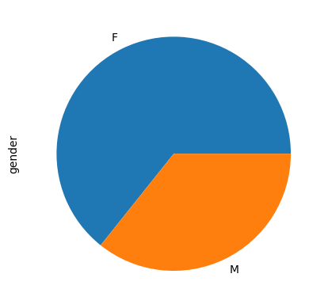

```python
df.gender.value_counts().plot(kind='pie');
```

```python
df.gender.value_counts()
```

```
F    40045
M    22253
Name: gender, dtype: int64
```

The number of females is greater than the number of males.

```python
df['gender'][attend].value_counts() , df['gender'][no_attend].value_counts()
```

```
(F    32217
 M    17888
 Name: gender, dtype: int64,
 F    7828
 M    4365
 Name: gender, dtype: int64)
```

As we can see, there are 7828 females and 4365 males who did not attend.

```python
df[attend].groupby('gender').age.mean() , df[no_attend].groupby('gender').age.mean()
```

```
(gender
 F    39.302573
 M    33.978924
 Name: age, dtype: float64,
 gender
 F    35.619699
 M    30.657961
 Name: age, dtype: float64)
```

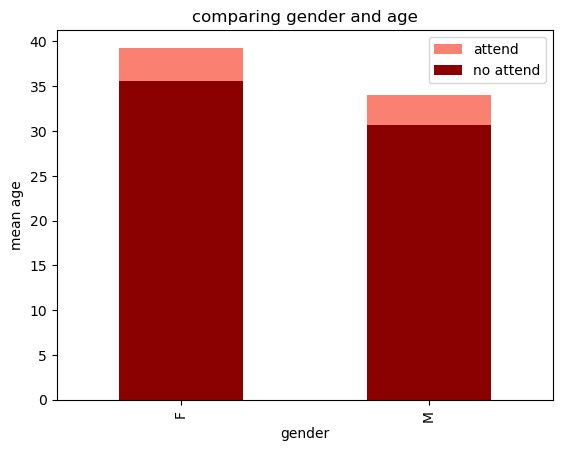

```python
# Does gender and age affect attendance?
df[attend].groupby('gender').age.mean().plot(kind='bar' , alpha= 1 ,color="salmon", label="attend")
df[no_attend].groupby('gender').age.mean().plot(kind='bar' , alpha= 1 ,color="darkred", label="no attend")
plt.legend();
plt.title('comparing gender and age')
plt.ylabel('mean age');
```

There is no significant effect of gender on attendance or non-attendance.

### Research Question 3 (Is there a relationship between age, gender, and disease?)

```python
df.head()
```

|  | gender | scheduledday | appointmentday | age | neighbourhood | scholarship | hypertension | diabetes | alcoholism | handicap | sms_received | no_show | age_stages |
| --- | --- | --- | --- | --- | --- | --- | --- | --- | --- | --- | --- | --- | --- |
| 0 | F | 2016-04-29 18:38:08+00:00 | 2016-04-29 00:00:00+00:00 | 62 | JARDIM DA PENHA | 0 | 1 | 0 | 0 | 0 | 0 | No | Elderly |
| 1 | M | 2016-04-29 16:08:27+00:00 | 2016-04-29 00:00:00+00:00 | 56 | JARDIM DA PENHA | 0 | 0 | 0 | 0 | 0 | 0 | No | Middle Age Adult |
| 2 | F | 2016-04-29 16:19:04+00:00 | 2016-04-29 00:00:00+00:00 | 62 | MATA DA PRAIA | 0 | 0 | 0 | 0 | 0 | 0 | No | Elderly |
| 3 | F | 2016-04-29 17:29:31+00:00 | 2016-04-29 00:00:00+00:00 | 8 | PONTAL DE CAMBURI | 0 | 0 | 0 | 0 | 0 | 0 | No | Childhood |
| 4 | F | 2016-04-29 16:07:23+00:00 | 2016-04-29 00:00:00+00:00 | 56 | JARDIM DA PENHA | 0 | 1 | 1 | 0 | 0 | 0 | No | Middle Age Adult |

```python
df.handicap.value_counts() , df.alcoholism.value_counts()
```

```
(0    61165
 1     1025
 2       99
 3        6
 4        3
 Name: handicap, dtype: int64,
 0    60792
 1     1506
 Name: alcoholism, dtype: int64)
```

```python
df.diabetes.value_counts() , df.hypertension.value_counts()
```

```
(0    57882
 1     4416
 Name: diabetes, dtype: int64,
 0    50056
 1    12242
 Name: hypertension, dtype: int64)
```

**As we can see, handicaps are separated into 5 unique values, and there is not much detail about each one, so I will change that to true and false, and as we can see there are a large number of patients suffering from hypertension and diabetes.**

```python
for X in [1,2,3,4]:
    df['handicap'].replace(X,1,inplace=True)
```

```python
# checking the values
df.handicap.value_counts()
```

```
0    61165
1     1133
Name: handicap, dtype: int64
```

```python
df[attend].groupby('handicap').age.mean() , df[no_attend].groupby('handicap').age.mean()
```

```
(handicap
 0    37.097693
 1    53.129338
 Name: age, dtype: float64,
 handicap
 0    33.597785
 1    50.054945
 Name: age, dtype: float64)
```

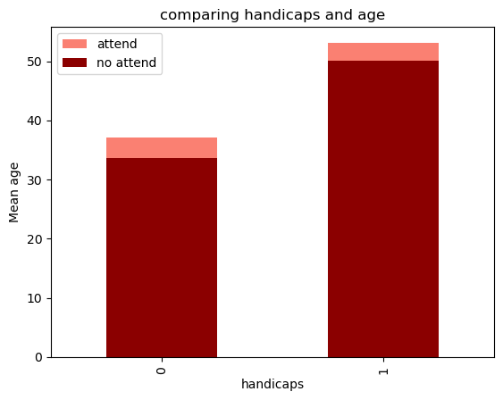

```python
# Is attendance affected by handicap and age?
df[attend].groupby('handicap').age.mean().plot(kind='bar' , alpha= 1 ,color="salmon", label="attend")
df[no_attend].groupby('handicap').age.mean().plot(kind='bar' , alpha= 1 ,color="darkred", label="no attend")
plt.legend();
plt.title('comparing handicaps and age')
plt.xlabel('handicaps')
plt.ylabel('Mean age');
```

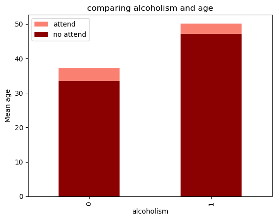

```python
# Is attendance affected by alcoholism and age?
df[attend].groupby('alcoholism').age.mean().plot(kind='bar' , alpha= 1 ,color="salmon", label="attend")
df[no_attend].groupby('alcoholism').age.mean().plot(kind='bar' , alpha= 1 ,color="darkred", label="no attend")
plt.legend();
plt.title('comparing alcoholism and age')
plt.xlabel('alcoholism')
plt.ylabel('Mean age');
```

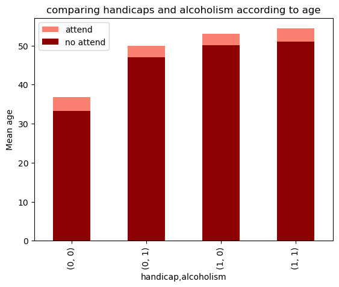

```python
# Does handicap and alcoholism according to age have an impact?
df[attend].groupby(['handicap','alcoholism']).age.mean().plot(kind='bar',alpha= 1 ,color="salmon", label="attend")
df[no_attend].groupby(['handicap','alcoholism']).age.mean().plot(kind='bar',alpha= 1 ,color="darkred", label="no attend")
plt.legend()
plt.title('comparing handicaps and alcoholism according to age')
plt.ylabel('Mean age');
```

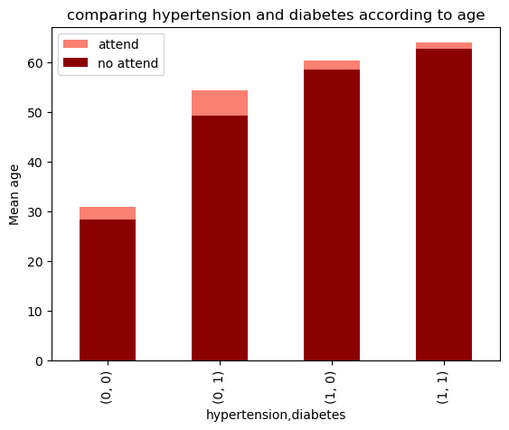

```python
# Does hypertension and diabetes according to age have an impact?
df[attend].groupby(['hypertension','diabetes']).age.mean().plot(kind='bar',alpha= 1 ,color="salmon", label="attend")
df[no_attend].groupby(['hypertension','diabetes']).age.mean().plot(kind='bar',alpha= 1 ,color="darkred", label="no attend")
plt.legend()
plt.title('comparing hypertension and diabetes according to age')
plt.ylabel('Mean age');
```

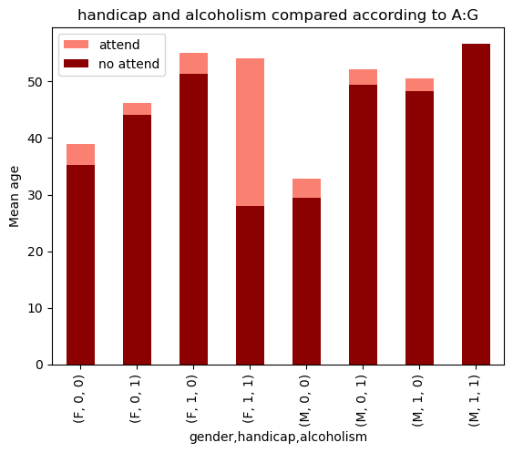

```python
# Does handicap and alcoholism affect attendance based on gender and age?
df[attend].groupby(['gender','handicap','alcoholism']).age.mean().plot(kind='bar',alpha= 1 ,color="salmon", label="attend")
df[no_attend].groupby(['gender','handicap','alcoholism']).age.mean().plot(kind='bar',alpha= 1 ,color="darkred", label="no attend")
plt.legend()
plt.title('handicap and alcoholism compared according to A:G')
plt.ylabel('Mean age');
```

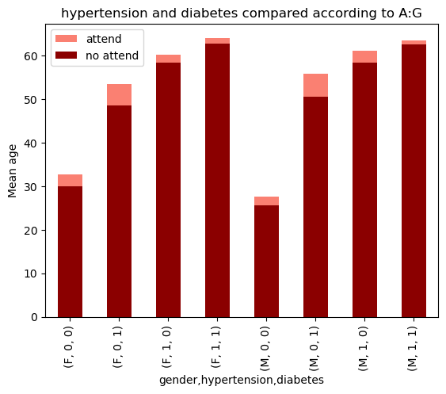

```python
# Does hypertension and diabetes affect attendance based on gender and age?
df[attend].groupby(['gender','hypertension','diabetes']).age.mean().plot(kind='bar',alpha= 1 ,color="salmon", label="attend")
df[no_attend].groupby(['gender','hypertension','diabetes']).age.mean().plot(kind='bar',alpha= 1 ,color="darkred", label="no attend")
plt.legend()
plt.title('hypertension and diabetes compared according to A:G')
plt.ylabel('Mean age');
```

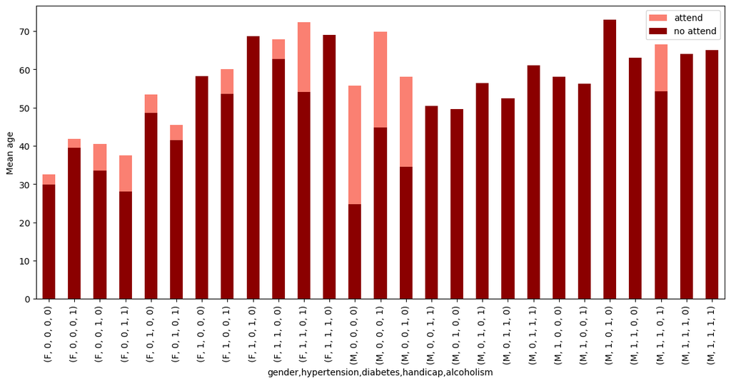

```python
plt.figure(figsize=(14,6))
df[attend].groupby(['gender','hypertension','diabetes','handicap','alcoholism']).age.mean().plot(kind='bar',alpha= 1 ,color="salmon", label="attend")
df[no_attend].groupby(['gender','hypertension','diabetes','handicap','alcoholism']).age.mean().plot(kind='bar',alpha= 1 ,color="darkred", label="no attend")
plt.legend()
plt.title('')
plt.ylabel('Mean age');
```

### Research Question 4 (Is there a relationship between sms and non-attendance?)

```python
df.head()
```

|  | gender | scheduledday | appointmentday | age | neighbourhood | scholarship | hypertension | diabetes | alcoholism | handicap | sms_received | no_show | age_stages |
| --- | --- | --- | --- | --- | --- | --- | --- | --- | --- | --- | --- | --- | --- |
| 0 | F | 2016-04-29 18:38:08+00:00 | 2016-04-29 00:00:00+00:00 | 62 | JARDIM DA PENHA | 0 | 1 | 0 | 0 | 0 | 0 | No | Elderly |
| 1 | M | 2016-04-29 16:08:27+00:00 | 2016-04-29 00:00:00+00:00 | 56 | JARDIM DA PENHA | 0 | 0 | 0 | 0 | 0 | 0 | No | Middle Age Adult |
| 2 | F | 2016-04-29 16:19:04+00:00 | 2016-04-29 00:00:00+00:00 | 62 | MATA DA PRAIA | 0 | 0 | 0 | 0 | 0 | 0 | No | Elderly |
| 3 | F | 2016-04-29 17:29:31+00:00 | 2016-04-29 00:00:00+00:00 | 8 | PONTAL DE CAMBURI | 0 | 0 | 0 | 0 | 0 | 0 | No | Childhood |
| 4 | F | 2016-04-29 16:07:23+00:00 | 2016-04-29 00:00:00+00:00 | 56 | JARDIM DA PENHA | 0 | 1 | 1 | 0 | 0 | 0 | No | Middle Age Adult |

```python
df.sms_received.value_counts()
```

```
0    41904
1    20394
Name: sms_received, dtype: int64
```

**As we can see, a large number of SMS were not received.**

```python
df['sms_received'][attend].value_counts()  , df['sms_received'][no_attend].value_counts()
```

```
(0    35202
 1    14903
 Name: sms_received, dtype: int64,
 0    6702
 1    5491
 Name: sms_received, dtype: int64)
```

**35202 patients attend without receiving SMS, and 14903 attend with SMS. 6702 didn't attend without SMS. 5491 didn't attend with SMS.**

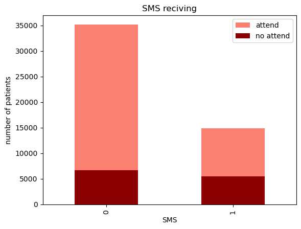

```python
# Does SMS affect attendance?
df['sms_received'][attend].value_counts().plot(kind='bar',alpha= 1 ,color="salmon", label="attend")
df['sms_received'][no_attend].value_counts().plot(kind='bar',alpha= 1 ,color="darkred", label="no attend")
plt.legend();
plt.title('SMS reciving')
plt.xlabel('SMS');
plt.ylabel('number of patients');
```

**As we can see, patients who do not receive SMS are more committed to their appointments.**

### Research Question 5 (Does neighbourhood affect attendance?)

```python
df.head()
```

|  | gender | scheduledday | appointmentday | age | neighbourhood | scholarship | hypertension | diabetes | alcoholism | handicap | sms_received | no_show | age_stages |
| --- | --- | --- | --- | --- | --- | --- | --- | --- | --- | --- | --- | --- | --- |
| 0 | F | 2016-04-29 18:38:08+00:00 | 2016-04-29 00:00:00+00:00 | 62 | JARDIM DA PENHA | 0 | 1 | 0 | 0 | 0 | 0 | No | Elderly |
| 1 | M | 2016-04-29 16:08:27+00:00 | 2016-04-29 00:00:00+00:00 | 56 | JARDIM DA PENHA | 0 | 0 | 0 | 0 | 0 | 0 | No | Middle Age Adult |
| 2 | F | 2016-04-29 16:19:04+00:00 | 2016-04-29 00:00:00+00:00 | 62 | MATA DA PRAIA | 0 | 0 | 0 | 0 | 0 | 0 | No | Elderly |
| 3 | F | 2016-04-29 17:29:31+00:00 | 2016-04-29 00:00:00+00:00 | 8 | PONTAL DE CAMBURI | 0 | 0 | 0 | 0 | 0 | 0 | No | Childhood |
| 4 | F | 2016-04-29 16:07:23+00:00 | 2016-04-29 00:00:00+00:00 | 56 | JARDIM DA PENHA | 0 | 1 | 1 | 0 | 0 | 0 | No | Middle Age Adult |

```python
df['neighbourhood'].nunique()
```

```
81
```

```python
df['neighbourhood'].value_counts()
```

```
JARDIM CAMBURI                 4192
MARIA ORTIZ                    3336
JARDIM DA PENHA                2406
RESISTÊNCIA                    2373
ITARARÉ                        2136
                               ...
ILHA DO BOI                      22
AEROPORTO                         7
ILHA DO FRADE                     5
ILHAS OCEÂNICAS DE TRINDADE       2
PARQUE INDUSTRIAL                 1
Name: neighbourhood, Length: 81, dtype: int64
```

```python
df['neighbourhood'][attend].value_counts() , df['neighbourhood'][no_attend].value_counts()
```

```
(JARDIM CAMBURI       3421
 MARIA ORTIZ          2647
 JARDIM DA PENHA      2010
 RESISTÊNCIA          1904
 ITARARÉ              1616
                      ...
 PONTAL DE CAMBURI      38
 ILHA DO BOI            21
 AEROPORTO               6
 ILHA DO FRADE           4
 PARQUE INDUSTRIAL       1
 Name: neighbourhood, Length: 80, dtype: int64,
 JARDIM CAMBURI                 771
 MARIA ORTIZ                    689
 ITARARÉ                        520
 RESISTÊNCIA                    469
 JARDIM DA PENHA                396
                               ...
 PONTAL DE CAMBURI                7
 ILHAS OCEÂNICAS DE TRINDADE      2
 ILHA DO BOI                      1
 AEROPORTO                        1
 ILHA DO FRADE                    1
 Name: neighbourhood, Length: 80, dtype: int64)
```

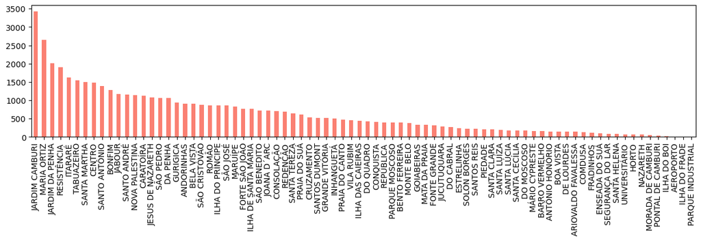

```python
plt.figure(figsize=(15,3))
df['neighbourhood'][attend].value_counts().plot(kind='bar',alpha= 1 ,color="salmon");
```

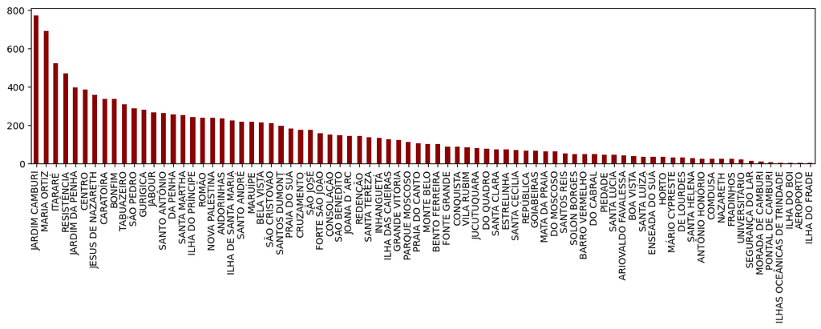

```python
plt.figure(figsize=(15,3))
df['neighbourhood'][no_attend].value_counts().plot(kind='bar',alpha= 1 ,color="darkred");
```

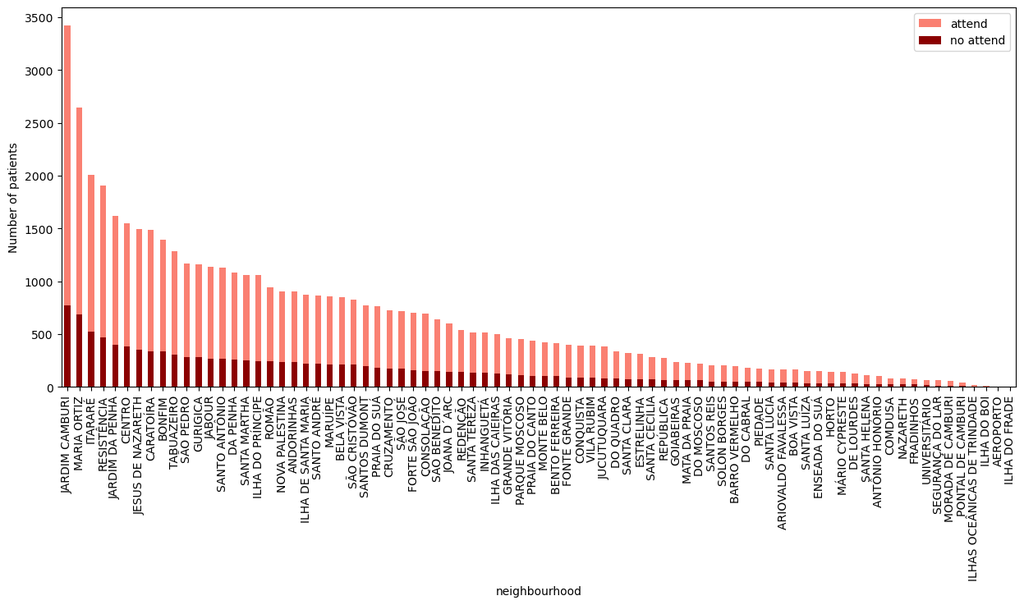

```python
# Does the neighbourhoods affect attendance?
plt.figure(figsize=(15,6))
df['neighbourhood'][attend].value_counts().plot(kind='bar',alpha= 1 ,color="salmon" ,label='attend');
df['neighbourhood'][no_attend].value_counts().plot(kind='bar',alpha= 1 ,color="darkred",label='no attend');
plt.legend()
plt.xlabel('neighbourhood')
plt.ylabel('Number of patients');
```

## limitations

There is no relationship between gender and attending the appointment.

```python
from subprocess import call
call(['python', '-m', 'nbconvert', 'Investigate_a_Dataset.ipynb'])
```

```
1
```